# Scrape the Congressional Record with `rvest`

# Scrape URLs for every subsection of the Congressional Record

As we do so, we retain some helpful metadata

- The record is divided by date
- The record is divided into three sections: Senate, House, Extensions of Remarks (text submitted to the record later)
- The page number (“S3253” is the 3,253rd page of the record, featuring remarks from the Senate)

For each day of the congressional record has a page: https://www.congress.gov/congressional-record/2017/6/6/senate-section

On this page are URLs for each subsection. These URLs look like this: https://www.congress.gov/congressional-record/2017/6/6/senate-section/article/S3253-6

We can identify linked text (`html_nodes("a")`), and put the URLs (`html_attr("href")`) and their text (`html_text()`) for each date and each section of the record into a data frame. With `map_dfr` from the `purrr` package, we can then apply this to a range of dates.

```r
# a date range to scrape
dates <- seq(as.Date("2020/01/01"),
             # as.Date("2020/09/01"),
             Sys.Date(), # today
             by = "day")

# a function to make a data frame of of all cr text urls for a date
get_cr_df <- function(date, section){

  url <- str_c("https://www.congress.gov/congressional-record",
             date %>% str_replace_all("-", "/"),
             section, sep = "/")

  pages <- read_html(url) %>%
    html_nodes("a") # "a" nodes are linked text

d <- tibble(header = html_text(pages), # the text of the linked text
            date = date,
            section = section,
            url = str_c("https://www.congress.gov",
                         html_attr(pages, "href") # urls are "href" attributes of linked text
                         )
            ) %>%
  # trim down to html txt pages
  filter(url %>% str_detect("article"))

return(d)
}

  ## For testing
    # section <- "senate-section"
    # date <- "2020-09-15"
    # get_cr_df(date, section)

# an empty dataframe for failed calls
d_init <-  tibble(header = "",
                  date = as.Date(NA),
                  section = "",
                  url = "")

# a dataframe of headers, dates, and url paths
senate <- map_dfr(dates, .f = possibly(get_cr_df, otherwise = d_init), section = "senate-section")

house <- map_dfr(dates, .f = possibly(get_cr_df, otherwise = d_init), section = "house-section")

ext <- map_dfr(dates, .f = possibly(get_cr_df, otherwise = d_init), section = "extensions-of-remarks-section")

cr_metadata <- full_join(senate, house) %>%
  full_join(ext)

# drop dates where for which there is no record
cr_metadata %<>% filter(header != "")
```

```r
  d <- cr_metadata
  load(here::here("data", "cr_metadata.Rdata"))
  cr_metadata %<>% full_join(d)
  save(cr_metadata, file = here::here("data", "cr_metadata.Rdata"))
```

# Option 1: Download the text of the congressional record

The “View TXT in new window” URL takes us to a .htm file of just the congressional record text. Compared to the much larger .html of the main page, the (minimal) downside is that some of the header information is lost (nothing distinguishes main headers from subheaders).

`html_session() %>% follow_link("View TXT in new window")` takes us to the raw TXT page. With `walk` from the `purrr` package, we can download each raw txt page to a file with the same name.

```r
# already downloaded
downloaded <- list.files(here::here("data", "htm"))

# a function to download htm
get_cr_htm <- function(url){

  ## test
  # url <- "https://www.congress.gov/congressional-record/2020/03/02/senate-section/article/S1255-1"

  # follow the link to the txt htm
  url %<>%
    html_session() %>%
    follow_link("View TXT in new window")

  # name files the end of the url
  file <- str_remove(url$url, ".*modified/")

  # if the file has not already been downloaded
  if(!file %in% downloaded){
      read_html(url) %>%
      write_html(file = here::here("data","htm", file))
  }
}

## test
# get_cr_htm(cr_metadata$url[1])

# download file for each url
walk(cr_metadata$url, get_cr_htm)
```

TXT pages look like this: https://www.congress.gov/115/crec/2017/06/06/modified/CREC-2017-06-06-pt1-PgS3253-6.htm

```r
read_html("https://www.congress.gov/115/crec/2017/06/06/modified/CREC-2017-06-06-pt1-PgS3253-6.htm") %>% html_text() %>% str_split("\n") %>% kablebox()
```

| x |
| --- |
| [Pages S3253-S3254] |
| From the Congressional Record Online through the Government Publishing Office [www.gpo.gov] |
| DEPARTMENT OF VETERANS AFFAIRS ACCOUNTABILITY AND WHISTLEBLOWER |
| PROTECTION BILL |
| Mr. McCONNELL. Now, Mr. President, on another matter, like those who |
| have called for relief from ObamaCare, many Americans across the Nation |
| are counting on us to ensure better quality healthcare for our |
| veterans. This is a critical issue for each of us no matter what State |
| we come from, no matter what party we represent. Our veterans have |
| sacrificed too much. In return, they deserve our support. We must keep |
| the commitment we have to them when it comes to ensuring that the VA is |
| providing the quality healthcare they rely on. |
| Unfortunately, as we all know, many VA facilities across the Nation |
| have long failed to provide our Nation’s heroes with the timely and |
| effective medical attention they need. Already, Congress has taken a |
| number of steps to improve these facilities for our veterans and to |
| keep the faith for those |
| [[Page S3254]] |
| who have willingly and courageously fought on our behalf. |
| Now we can build on those efforts by passing the Department of |
| Veterans Affairs Accountability and Whistleblower Protection Act. As |
| the name implies, this legislation will enhance accountability measures |
| at the VA and better enable the Department to remove–to remove– |
| employees who are failing to meet the standards expected of them. |
| This bill, in conjunction with the continued administration efforts |
| like those Secretary Shulkin announced yesterday, will further improve |
| medical services offered to our veterans at VA facilities all across |
| our country. It was unfortunate to see this legislation held up in a |
| previous Congress, but I am proud that the Republican Senate has made |
| its passage among our top priorities. |
| I once again recognize Veterans’ Affairs Committee chairman Johnny |
| Isakson and Senator Rubio for the part they played in moving this very |
| important bill forward and remaining vigilant on behalf of America’s |
| veterans. I know we are all eager to advance it today and send it on |
| down to the White House for the President’s signature. |
| ____________________ |

# Option 2: Download the full HTML

The full HTML of the landing page for each subsection appears to have some metadata beyond the TXT files.

- main subject headers
- possibly speaker IDs (speeches appear to be tagged with member IDs, but I have yet to find them in the HTML)

> *CAUTION:* The full HTML is several GB per year!

```r
# make file path
cr_metadata %<>%
  mutate(file = str_c("CREC-",
                      date,"-",
                      # the file title
                      url %>% str_remove(".*article/"),
                      ".html"))

# already downloaded
downloaded <- list.files(here::here("data", "html"))

# a function to download html
get_cr_html <- function(url, file){
  message(url)
  if(!file %in% downloaded){
    url %>%
      read_html() %>%
      write_html(file = here::here("data", "html",file)
  }
}

## test
# get_cr(d$url[2], d$file[2])

start <- Sys.time()
walk2(cr_metadata$url, cr_metadata$file, get_cr_html)
Sys.time() - start
```

# Number of documents over time

### In all, we have 340762 documents from 2007-01-04 to 2020-09-22.

> **NOTE:** The plots below use the number of subsections and their headers. Thus, they only require the metadata from scraping the URLs, not the full text.

### By day

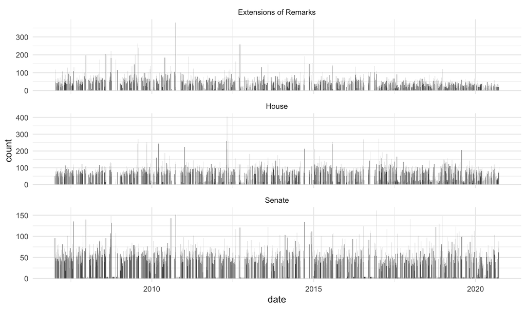

```r
# for plotting
cr_metadata %<>%
  mutate(year = str_sub(date, 1,4),
         chamber = section %>%
           str_remove("-.*") %>%
           str_to_title() %>%
           str_replace("Extensions", "Extensions of Remarks"))

cr_metadata %>%
  ggplot() +
  aes(x = date) +
  geom_bar() +
  facet_wrap("chamber", ncol = 1, scales = "free_y")
```

### By year

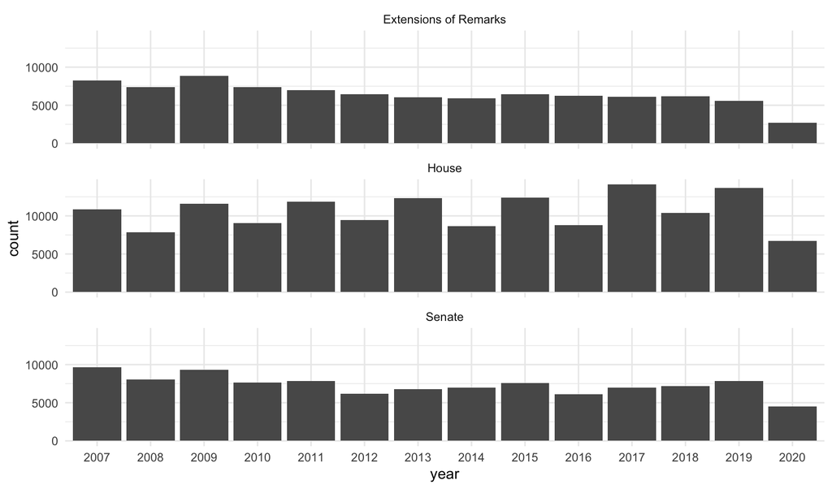

```r
# for plotting
cr_metadata %<>%
  mutate(year = str_sub(date, 1,4),
         chamber = section %>%
           str_remove("-.*") %>%
           str_to_title() %>%
           str_replace("Extensions", "Extensions of Remarks"))

cr_metadata %>%
  ggplot() +
  aes(x = year) +
  geom_bar() +
  facet_wrap("chamber", ncol = 1)
```

## Headers mentioning COVID19

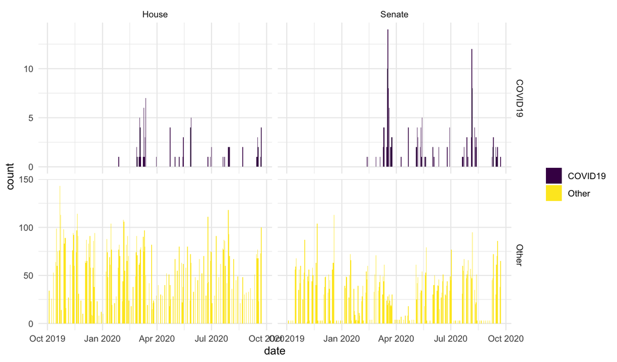

```r
cr_metadata %<>%
  # id sections about COVID19
  mutate(covid = ifelse(str_detect(header, "COVID|CORONA"), "COVID19", "Other") )

cr_metadata %>%
  filter(date > as.Date("2019-10-01"),
         chamber != "Extensions of Remarks") %>%
  ggplot() +
  aes(x = date, fill = covid) +
  geom_bar() +
  labs(fill = "") +
  facet_grid(covid ~ chamber, scales = "free_y")
```

321 documents have “COVID” or “coronavirus” in their header.

## Headers mentioning redistricting or gerrymandering

```r
cr_metadata %<>%
  # id sections about redistricting
  mutate(dist = ifelse(str_detect(header, "GERRYMANDER|REDISTRICT"), "Gerrymandering", "Other") )

cr_metadata %>%
  filter(dist == "Gerrymandering") %>%
  select(date, header, url) %>%
  kablebox()
```

| date | header | url |
| --- | --- | --- |
| 2019-03-08 | REDISTRICTING REFORM; Congressional Record Vol. 165, No. 42 | https://www.congress.gov/congressional-record/2019/03/08/house-section/article/H2589-7 |
| 2017-04-27 | CONGRESSIONAL REDISTRICTING; Congressional Record Vol. 163, No. 72 | https://www.congress.gov/congressional-record/2017/04/27/house-section/article/H2908-4 |
| 2017-01-27 | INTRODUCTION OF JOHN TANNER FAIRNESS AND INDEPENDENCE IN REDISTRICTING ACT; Congressional Record Vol. 163, No. 14 | https://www.congress.gov/congressional-record/2017/01/27/extensions-of-remarks-section/article/E95-3 |
| 2011-11-15 | A NATIONAL REDISTRICTING COMMISSION; Congressional Record Vol. 157, No. 174 | https://www.congress.gov/congressional-record/2011/11/15/house-section/article/H7581-4 |
| 2008-07-29 | GERRYMANDERING | https://www.congress.gov/congressional-record/2008/07/29/house-section/article/H7284-3 |

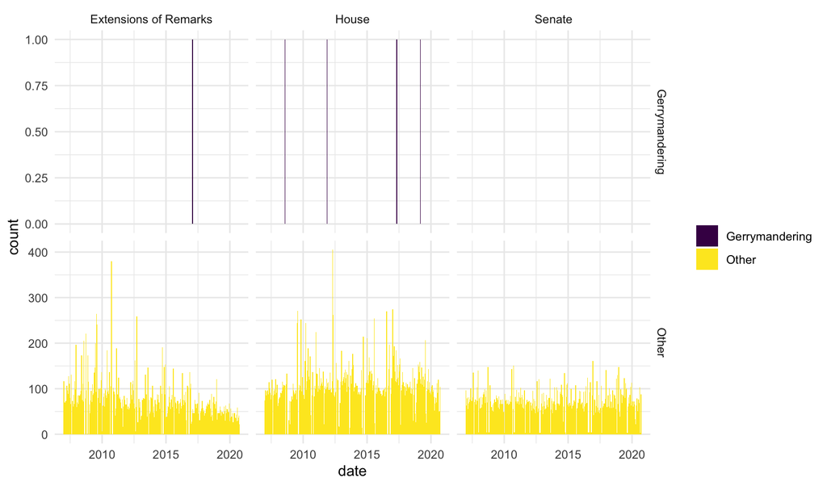

```r
cr_metadata %>%
  ggplot() +
  aes(x = date, fill = dist) +
  geom_bar(width = 20) +
  labs(fill = "") +
  facet_grid(dist ~ chamber, scales = "free_y")
```

5 documents have “redistrict” or “gerrymander” in their header.

## Most common headers

```r
# clean up headers
cr_metadata %<>%
         mutate(subtype = header %>%
           toupper() %>%
           str_remove(";.*") %>%
           str_replace(".*ACT.*", "ACT") %>%
             str_replace("MESSAGE ", "MESSAGES ") %>%
             str_replace("CONDEMNING.*", "CONDEMNING") %>%
           str_remove_all(" BY .*| UNTIL.*| \\(EXECUTIVE.*")
         )

# top 100 headers
cr_metadata %>%
  count(subtype, sort = T) %>%
  head(100) %>%
  kablebox()
```

| subtype | n |
| --- | --- |
| ACT | 29254 |
| PERSONAL EXPLANATION | 7585 |
| ADJOURNMENT | 4314 |
| PLEDGE OF ALLEGIANCE | 4097 |
| PRAYER | 4004 |
| ANNOUNCEMENT | 3815 |
| RECESS | 2945 |
| THE JOURNAL | 2508 |
| MORNING BUSINESS | 2459 |
| SENATE | 2438 |
| HOUSE OF REPRESENTATIVES | 2341 |
| AFTER RECESS | 2188 |
| PUBLIC BILLS AND RESOLUTIONS | 2107 |
| ADDITIONAL SPONSORS | 2069 |
| EXECUTIVE COMMUNICATIONS, ETC. | 2052 |
| ADDITIONAL COSPONSORS | 1937 |
| INTRODUCTION OF BILLS AND JOINT RESOLUTIONS | 1917 |
| RESERVATION OF LEADER TIME | 1753 |
| ADDITIONAL STATEMENTS | 1749 |
| RECOGNITION OF THE MAJORITY LEADER | 1723 |
| LEGISLATIVE SESSION | 1716 |
| EARMARK DECLARATION | 1643 |
| SUBMISSION OF CONCURRENT AND SENATE RESOLUTIONS | 1627 |
| SUBMITTED RESOLUTIONS | 1624 |
| EXECUTIVE SESSION | 1583 |
| REPORTS OF COMMITTEES ON PUBLIC BILLS AND RESOLUTIONS | 1579 |
| CONSTITUTIONAL AUTHORITY STATEMENT | 1552 |
| STATEMENTS ON INTRODUCED BILLS AND JOINT RESOLUTIONS | 1523 |
| MESSAGES FROM THE HOUSE | 1511 |
| AMENDMENTS SUBMITTED AND PROPOSED | 1411 |

[output cut: 70 more lines]

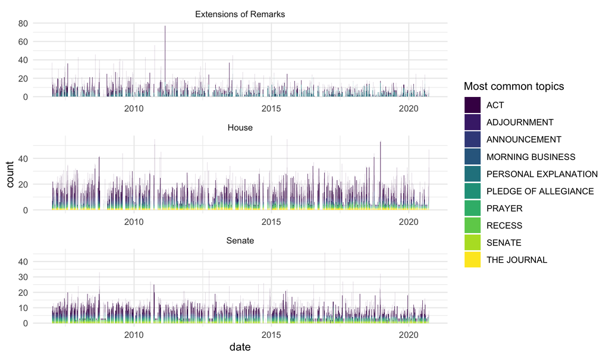

```r
top10 <- cr_metadata %>% count(subtype, sort = T) %>% .$subtype %>% head(10)

cr_metadata %>%
  filter(subtype %in% top10) %>%
  ggplot() +
  aes(x = date, fill = subtype) +
  geom_bar(width = .9) +
  labs(fill = "Most common topics") +
  facet_wrap("chamber", ncol = 1, scales = "free")
```

## Most discussed acts

```r
# top 100 headers
cr_metadata %>%
  filter(str_detect(header, " ACT( |$)")) %>%
  count(header, sort = T) %>%
  head(100) %>%
  kablebox()
```

| header | n |
| --- | --- |
| NATIONAL DEFENSE AUTHORIZATION ACT FOR FISCAL YEAR 2008 | 28 |
| FARM, NUTRITION, AND BIOENERGY ACT OF 2007 | 26 |
| NATIONAL DEFENSE AUTHORIZATION ACT FOR FISCAL YEAR 2011; Congressional Record Vol. 156, No. 83 | 26 |
| MIDDLE CLASS HEALTH BENEFITS TAX REPEAL ACT OF 2019; Congressional Record Vol. 166, No. 63 | 23 |
| ENERGY INDEPENDENCE AND SECURITY ACT OF 2007 | 21 |
| PAUL WELLSTONE MENTAL HEALTH AND ADDICTION EQUITY ACT OF 2007 | 21 |
| THE MATTHEW SHEPARD ACT OF 2007 | 19 |
| EMPLOYEE FREE CHOICE ACT | 18 |
| HOWARD P. ``BUCK’’ McKEON NATIONAL DEFENSE AUTHORIZATION ACT FOR FISCAL YEAR 2015; Congressional Record Vol. 160, No. 78 | 18 |
| STEM CELL RESEARCH ENHANCEMENT ACT OF 2007 | 18 |
| STUDENT AID AND FISCAL RESPONSIBILITY ACT OF 2009; Congressional Record Vol. 155, No. 132 | 18 |
| WALL STREET REFORM AND CONSUMER PROTECTION ACT OF 2009; Congressional Record Vol. 155, No. 186 | 18 |
| FEDERAL AGRICULTURE REFORM AND RISK MANAGEMENT ACT OF 2013; Congressional Record Vol. 159, No. 89 | 17 |
| FISA AMENDMENTS ACT OF 2008 | 17 |
| FAIR MINIMUM WAGE ACT OF 2007 | 16 |
| COLLEGE STUDENT RELIEF ACT OF 2007 | 15 |
| HOUSING AND ECONOMIC RECOVERY ACT OF 2008 | 15 |
| NATIONAL DEFENSE AUTHORIZATION ACT FOR FISCAL YEAR 2013; Congressional Record Vol. 158, No. 72 | 15 |
| AMERICAN HOUSING RESCUE AND FORECLOSURE PREVENTION ACT OF 2008 | 14 |
| MOTION TO INSTRUCT CONFEREES ON H.R. 2419, FOOD AND ENERGY SECURITY ACT OF 2007 | 14 |
| AMERICA COMPETES ACT | 13 |
| CHILDREN’S HEALTH INSURANCE PROGRAM REAUTHORIZATION ACT OF 2007 | 13 |
| FOREIGN INTELLIGENCE SURVEILLANCE ACT | 13 |
| HELPING FAMILIES SAVE THEIR HOMES ACT OF 2009; Congressional Record Vol. 155, No. 39 | 13 |
| MATTHEW SHEPARD ACT OF 2007 | 13 |
| DUNCAN HUNTER NATIONAL DEFENSE AUTHORIZATION ACT FOR FISCAL YEAR 2009 | 12 |
| FISA AMENDMENTS ACT OF 2007 | 12 |
| NATIONAL DEFENSE AUTHORIZATION ACT FOR FISCAL YEAR 2014; Congressional Record Vol. 159, No. 85 | 12 |
| PROTECTING THE MEDICAID SAFETY NET ACT OF 2008 | 12 |
| TRANSPARENCY IN REGULATORY ANALYSIS OF IMPACTS ON THE NATION ACT OF 2011; Congressional Record Vol. 157, No. 143 | 12 |

[output cut: 70 more lines]

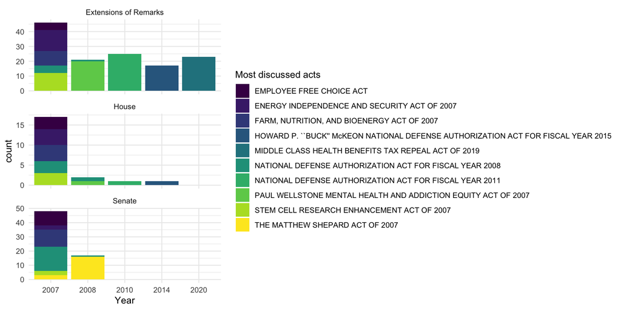

```r
top10 <- cr_metadata %>%
  filter(str_detect(header, " ACT( |$)")) %>%
  count(header, sort = T) %>% .$header %>% head(10)

cr_metadata %>%
  filter(header %in% top10) %>%
  mutate(header = header %>% str_remove(";.*")) %>%
  ggplot() +
  aes(x = factor(year), fill = header) +
  geom_bar(width = .9) +
  labs(fill = "Most discussed acts",
       x = "Year") +
  facet_wrap("chamber", ncol = 1, scales = "free_y")
```

# Text features

```r
cr <- list.files("/Users/devin/cr_bulk/data/htm")

d <- tibble(file = cr,
       date = str_extract(cr, "[0-9]{4}-[0-9]{2}-[0-9]{2}") %>%
         as.Date)

#FIXME
d %<>% filter(date > as.Date("2019-03-01"),
              date < as.Date("2019-03-09"))


d %<>% mutate(url = str_c("https://www.congress.gov/116/crec/",
                          date %>% str_replace_all("-", "/"),
                          "/modified/",
                          file))
#/FIXME

# a function to grab sentences with keywords
keyword_sentence <- function(file, word){
  text <- read_lines(str_c("/Users/devin/cr_bulk/data/htm/", file)) %>%
    str_c(collapse = " ") %>%
    str_squish()

  if( str_detect(text, regex(word, ignore_case = T) ) ){
     text %<>%
      enframe(name = NULL, value = "text") %>%
      unnest_tokens(sentence, text, token = "sentences") %>%
      filter(str_detect(sentence, word)) %>%
      .$sentence %>%
      str_c(collapse = "...")
  } else {
    text <- "NA"
  }

  return(text)
}

## test
# keyword_sentence(d$file[1], "speaker")
```

Sentences containing “speaker” on 2019-03-08

(a good test because most speaches in the House address the speaker)

```r
d %>%
  filter(date == max(d$date) ) %>%
  mutate(sentence = map_chr(file, .f = keyword_sentence, word = "speaker") ) %>%
  select(date, sentence, url) %>% kablebox()
```

| date | sentence | url |
| --- | --- | --- |
| 2019-03-08 | madam speaker, i rise today to recognize and applaud erica bassett for receiving the arvada wheat ridge service ambassadors for youth award. | https://www.congress.gov/116/crec/2019/03/08/modified/CREC-2019-03-08-pt1-PgE271-2.htm |
| 2019-03-08 | madam speaker, i rise today to recognize ms….madam speaker, i urge my colleagues to join me in commending and congratulating ms. | https://www.congress.gov/116/crec/2019/03/08/modified/CREC-2019-03-08-pt1-PgE271-3.htm |
| 2019-03-08 | delauro, madam speaker, i rise to honor late congressman walter jones, jr. | https://www.congress.gov/116/crec/2019/03/08/modified/CREC-2019-03-08-pt1-PgE271-4.htm |
| 2019-03-08 | madam speaker, i rise today to recognize and applaud zekariya bearce for receiving the arvada wheat ridge service ambassadors for youth award. | https://www.congress.gov/116/crec/2019/03/08/modified/CREC-2019-03-08-pt1-PgE271-5.htm |
| 2019-03-08 | madam speaker, i rise to congratulate the educators serving in the prince william county public schools division on obtaining certification or recertification by the national board for professional te… | https://www.congress.gov/116/crec/2019/03/08/modified/CREC-2019-03-08-pt1-PgE271-6.htm |
| 2019-03-08 | madam speaker, i rise today to recognize and applaud lorenzo becerra for receiving the arvada wheat ridge service ambassadors for youth award. | https://www.congress.gov/116/crec/2019/03/08/modified/CREC-2019-03-08-pt1-PgE272-2.htm |
| 2019-03-08 | madam speaker, i rise today to honor and remember the life of jay a. | https://www.congress.gov/116/crec/2019/03/08/modified/CREC-2019-03-08-pt1-PgE272-3.htm |
| 2019-03-08 | NA | https://www.congress.gov/116/crec/2019/03/08/modified/CREC-2019-03-08-pt1-PgE272-4.htm |
| 2019-03-08 | madam speaker, i rise today to recognize and applaud jayla boiter for receiving the arvada wheat ridge service ambassadors for youth award. | https://www.congress.gov/116/crec/2019/03/08/modified/CREC-2019-03-08-pt1-PgE272-5.htm |
| 2019-03-08 | madam speaker, i rise today proud of the passage of h.r. 1–the ‘for the people act.’ | https://www.congress.gov/116/crec/2019/03/08/modified/CREC-2019-03-08-pt1-PgE272.htm |
| 2019-03-08 | madam speaker, i rise today to recognize and applaud tydarrien bostic for receiving the arvada wheat ridge service ambassadors for youth award. | https://www.congress.gov/116/crec/2019/03/08/modified/CREC-2019-03-08-pt1-PgE273-2.htm |
| 2019-03-08 | madam speaker, i rise to recognize the incoming 2019 officers of the occoquan-woodbridge-lorton volunteer fire department….madam speaker, i ask that my colleagues join me in recognizing the men and wo… | https://www.congress.gov/116/crec/2019/03/08/modified/CREC-2019-03-08-pt1-PgE273-3.htm |
| 2019-03-08 | madam speaker, fifty-four years ago, in selma, alabama, hundreds of heroic souls risked their lives for freedom and to secure the right to vote for all americans by their participation in marches for … | https://www.congress.gov/116/crec/2019/03/08/modified/CREC-2019-03-08-pt1-PgE273-4.htm |
| 2019-03-08 | madam speaker, i missed votes on monday, march 5. | https://www.congress.gov/116/crec/2019/03/08/modified/CREC-2019-03-08-pt1-PgE273.htm |
| 2019-03-08 | madam speaker, i rise today to commemorate the two hundredth anniversary of the first steuben county fair. | https://www.congress.gov/116/crec/2019/03/08/modified/CREC-2019-03-08-pt1-PgE274-2.htm |
| 2019-03-08 | madam speaker, i rise today in support of h.r….madam speaker, voting is the very cornerstone of our democracy. | https://www.congress.gov/116/crec/2019/03/08/modified/CREC-2019-03-08-pt1-PgE274-3.htm |
| 2019-03-08 | madam speaker, i rise today to recognize and applaud elijah burk for receiving the arvada wheat ridge service ambassadors for youth award. | https://www.congress.gov/116/crec/2019/03/08/modified/CREC-2019-03-08-pt1-PgE274-4.htm |
| 2019-03-08 | madam speaker, i rise to recognize the tysons regional chamber of commerce and to congratulate the incoming 2019 board members….madam speaker, i ask that my colleagues join me in congratulating the in… | https://www.congress.gov/116/crec/2019/03/08/modified/CREC-2019-03-08-pt1-PgE274-5.htm |
| 2019-03-08 | madam speaker, i rise today to recognize and applaud shohzodakhon burhonova for receiving the arvada wheat ridge service ambassadors for youth award. | https://www.congress.gov/116/crec/2019/03/08/modified/CREC-2019-03-08-pt1-PgE274.htm |
| 2019-03-08 | madam speaker, i rise today to recognize and applaud mary bernadette chambers for receiving the arvada wheat ridge service ambassadors for youth award. | https://www.congress.gov/116/crec/2019/03/08/modified/CREC-2019-03-08-pt1-PgE275-2.htm |
| 2019-03-08 | madam speaker, i rise today to celebrate the life of richard chisolm, who passed away on monday, march 4th. | https://www.congress.gov/116/crec/2019/03/08/modified/CREC-2019-03-08-pt1-PgE275-3.htm |
| 2019-03-08 | madam speaker, i rise to recognize the vienna business association (vba) and to congratulate the incoming members of the 2019 board of directors….madam speaker, i ask that my colleagues join me in con… | https://www.congress.gov/116/crec/2019/03/08/modified/CREC-2019-03-08-pt1-PgE275-4.htm |
| 2019-03-08 | madam speaker, i rise today to express my excitement about the passage of h.r. | https://www.congress.gov/116/crec/2019/03/08/modified/CREC-2019-03-08-pt1-PgE275.htm |
| 2019-03-08 | madam speaker, the american legion is the largest veterans service organization in the united states. | https://www.congress.gov/116/crec/2019/03/08/modified/CREC-2019-03-08-pt1-PgE276-2.htm |
| 2019-03-08 | madam speaker, today i rise to honor steve sanders of the woodlands, texas in recognition of his dedication and service to our community and the state of texas. | https://www.congress.gov/116/crec/2019/03/08/modified/CREC-2019-03-08-pt1-PgE276-3.htm |
| 2019-03-08 | madam speaker, i rise today to recognize and applaud ashley coria for receiving the arvada wheat ridge service ambassadors for youth award. | https://www.congress.gov/116/crec/2019/03/08/modified/CREC-2019-03-08-pt1-PgE276-4.htm |
| 2019-03-08 | madam speaker, i rise today to recognize the nominees for the 2018-2019 prince william county public schools teacher of the year award….madam speaker, i ask that my colleagues join me in commending th… | https://www.congress.gov/116/crec/2019/03/08/modified/CREC-2019-03-08-pt1-PgE276-5.htm |
| 2019-03-08 | madam speaker, i rise today to recognize and applaud kristine chavoya-olivas for receiving the arvada wheat ridge service ambassadors for youth award. | https://www.congress.gov/116/crec/2019/03/08/modified/CREC-2019-03-08-pt1-PgE276.htm |
| 2019-03-08 | madam speaker, i rise today to recognize and honor the vietnam veterans of america (vva) from chapter 17 in las vegas, nevada. | https://www.congress.gov/116/crec/2019/03/08/modified/CREC-2019-03-08-pt1-PgE277-2.htm |
| 2019-03-08 | madam speaker, i rise to recognize chairman/ceo roger krone and the 32,000 employees of leidos on the occasion of the company’s 50th anniversary….[[page e278]] madam speaker, i ask my colleagues to jo… | https://www.congress.gov/116/crec/2019/03/08/modified/CREC-2019-03-08-pt1-PgE277-3.htm |

[output cut: 62 more lines]

Sentences containing “census” between 2019-03-04 and 2019-03-08

```r
d %>% mutate(sentence = map_chr(file, .f = keyword_sentence, word = "census") ) %>%
  filter(sentence != "NA") %>%
  select(date, sentence, url) %>% kablebox()
```

[output not shown]

Sentences containing “redistrict” “efficiency gap” or “gerrymander” between 2019-03-04 and 2019-03-08

```r
d %>% mutate(sentence = map_chr(file, .f = keyword_sentence, word = "redistrict|gerrymander|efficiency gap") ) %>%
  filter(sentence != "NA") %>%
  select(date, sentence, url) %>% kablebox()
```

| date | sentence | url |
| --- | --- | --- |
| 2019-03-05 | it will ensure every american can cast a ballot, end partisan gerrymandering, and reduce the influence of the ultrawealthy, corporations, and special interests. | https://www.congress.gov/116/crec/2019/03/05/modified/CREC-2019-03-05-pt1-PgH2342-5.htm |
| 2019-03-06 | i was tired of watching dark money grow, gerrymandering polarize our politics, and the american people pushed aside. | https://www.congress.gov/116/crec/2019/03/06/modified/CREC-2019-03-06-pt1-PgH2377-7.htm |
| 2019-03-06 | we are voting on h.r. 1, transformational legislation that will finally put the power back in the hands of the american people, by toughening federal ethics laws, fixing the broken campaign finance sy… | https://www.congress.gov/116/crec/2019/03/06/modified/CREC-2019-03-06-pt1-PgH2378-3.htm |
| 2019-03-06 | our elections are not free when americans must choose between providing for their families and casting a vote; our elections are not fair when gerrymandering predetermines them or dark money makes som… | https://www.congress.gov/116/crec/2019/03/06/modified/CREC-2019-03-06-pt1-PgH2378-4.htm |
| 2019-03-06 | i haven’t met a single person, republican or democrat, who thinks it is [[page h2379]] just fine for members of congress to serve on corporate boards or for presidents to hide their tax returns, or an… | https://www.congress.gov/116/crec/2019/03/06/modified/CREC-2019-03-06-pt1-PgH2378-6.htm |
| 2019-03-06 | we have a system of gerrymandering where in many parts of the country today, voters don’t choose their politicians, politicians choose their voters. | https://www.congress.gov/116/crec/2019/03/06/modified/CREC-2019-03-06-pt1-PgH2379-2.htm |
| 2019-03-06 | this legislation will end partisan gerrymandering by creating independent redistricting commissions, letting the voters choose the politicians, not the politicians choosing their voters. | https://www.congress.gov/116/crec/2019/03/06/modified/CREC-2019-03-06-pt1-PgH2379-4.htm |
| 2019-03-06 | in recent years, we have seen new forms of voter suppression emerge, whether in the guise of strict voter id laws, purges of voting rolls, partisan gerrymandering, or unfounded allegations of voter fr… | https://www.congress.gov/116/crec/2019/03/06/modified/CREC-2019-03-06-pt1-PgH2379-5.htm |
| 2019-03-06 | h.r. 1 will reform redistricting to ensure fairness in the process to guard against partisanship and respect communities of interest….it is a comprehensive, once-in-a- generation blueprint for reformi… | https://www.congress.gov/116/crec/2019/03/06/modified/CREC-2019-03-06-pt1-PgH2390-3.htm |
| 2019-03-06 | extreme political gerrymandering continues to skew state and congressional elections….aren’t we at that point now, where the vision of government of, by, and for the people has been corrupted by voter… | https://www.congress.gov/116/crec/2019/03/06/modified/CREC-2019-03-06-pt1-PgS1712-7.htm |
| 2019-03-07 | report on diversity of memberships of independent redistricting commissions….not later than may 15 of a year ending in the numeral one, the comptroller general of the united states shall submit to con… | https://www.congress.gov/116/crec/2019/03/07/modified/CREC-2019-03-07-pt1-PgH2555.htm |
| 2019-03-08 | this once in a generation legislation will increase access to the ballot box, end gerrymandering, and limit the influence of big money in politics. | https://www.congress.gov/116/crec/2019/03/08/modified/CREC-2019-03-08-pt1-PgE272-4.htm |
| 2019-03-08 | so again–let’s recap all the good h.r. 1 will do: it will increase access to the ballot box, end gerrymandering, create automatic voter registration; limit the power of restrictive voter id laws, and … | https://www.congress.gov/116/crec/2019/03/08/modified/CREC-2019-03-08-pt1-PgE272.htm |
| 2019-03-08 | it prohibits voter roll purges and ends partisan gerrymandering. | https://www.congress.gov/116/crec/2019/03/08/modified/CREC-2019-03-08-pt1-PgE274-3.htm |
| 2019-03-08 | doctype html public “-//w3c//dtd html 4.0 transitional//en” "[http://www.w3.org/tr/rec-html40/loose.dtd">](http://www.w3.org/tr/rec-html40/loose.dtd%22%3E); <html><body><pre> [pages h2589-h2590] from … | https://www.congress.gov/116/crec/2019/03/08/modified/CREC-2019-03-08-pt1-PgH2589-7.htm |
| 2019-03-08 | it was a good day to say that we are going to have redistricting which is not run by the politicians, and i have been one of them that has done it so everybody understands that….every state, not just … | https://www.congress.gov/116/crec/2019/03/08/modified/CREC-2019-03-08-pt1-PgH2603.htm |
| 2019-03-08 | h.r. 4, the voting rights advancement act, will erase these trends, and h.r. 1, which we passed today, strengthens democracy by ensuring clean, fair elections, prohibiting voter roll purges, and endin… | https://www.congress.gov/116/crec/2019/03/08/modified/CREC-2019-03-08-pt1-PgH2608.htm |

Sentences containing “partisan bias” between 2019-03-04 and 2019-03-08

```r
d %>% mutate(sentence = map_chr(file, .f = keyword_sentence, word = "partisan bias") ) %>%
  filter(sentence != "NA") %>%
  select(date, sentence, url) %>% kablebox()
```

| date | sentence | url |
| --- | --- | --- |
| 2019-03-06 | payments and grants. (a) in general.–the election assistance commission shall make grants to each eligible state to assist the state in implementing the requirements of this part (or, in the case of a… | https://www.congress.gov/116/crec/2019/03/06/modified/CREC-2019-03-06-pt1-PgH2390-3.htm |